# 01 단어 빈도 분석

단어 빈도 분석:

무엇을 강조했을까?

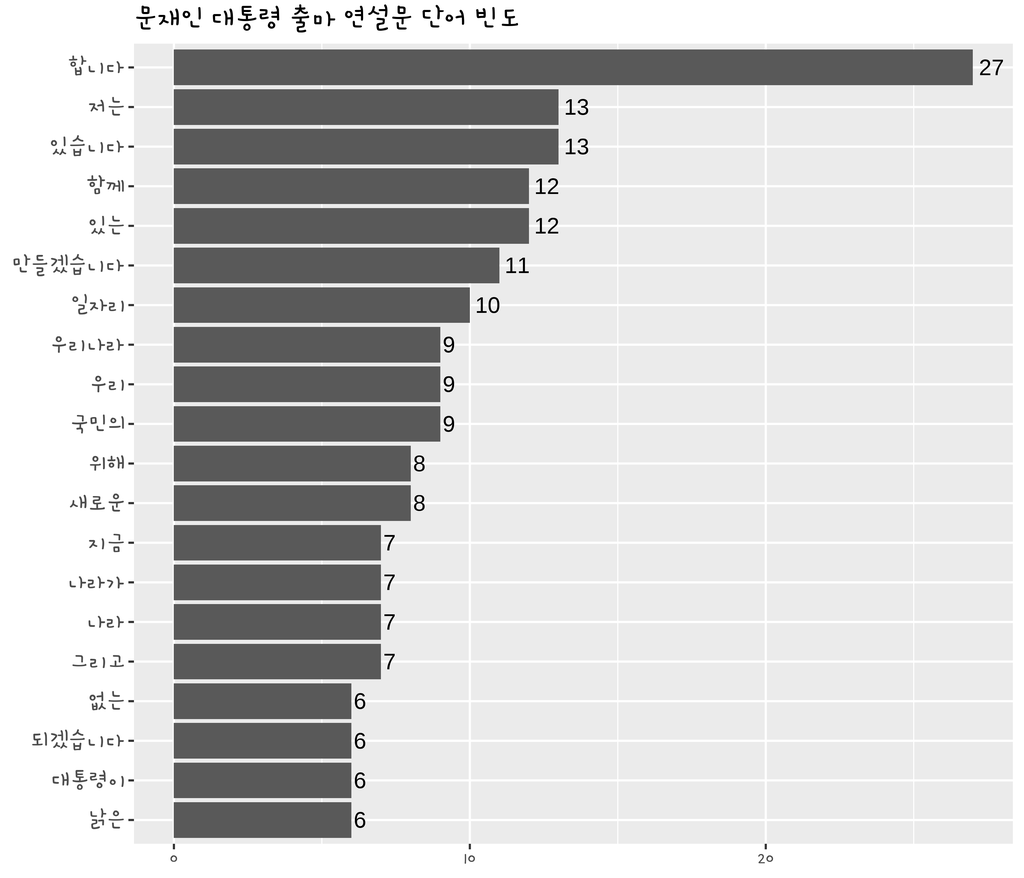

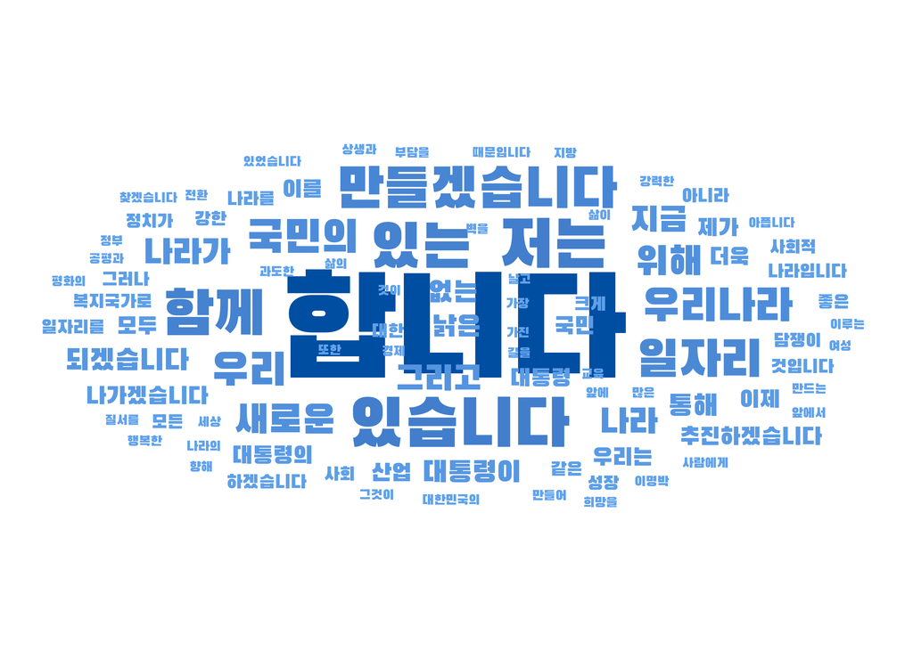

## 1 텍스트 전처리

- 텍스트에서 분석하는 데 불필요한 요소 제거
- 다루기 쉬운 형태로 만드는 과정

### 연설문 불러오기

```r
raw_moon <- readLines("speech_moon.txt", encoding = "UTF-8")

head(raw_moon)
```

```
## [1] "정권교체 하겠습니다!"
## [2] "  정치교체 하겠습니다!"
## [3] "  시대교체 하겠습니다!"
## [4] "  "
## [5] "  ‘불비불명(不飛不鳴)’이라는 고사가 있습니다. 남쪽 언덕 나뭇가지에 앉아, 3년 동안 날지도 울지도 않는 새. 그러나 그 새는 한번 날면 하늘 끝까지 날고, 한번 울면 천지를 뒤흔듭니다."
## [6] ""
```

- 문재인 대통령의 대선 출마 선언문 출처: bit.ly/easytext_11

### 불필요한 문자 제거하기 - `str_replace_all()`

- 분석 대상이 아닌 문자 제거
  - ex) 특수문자, 한자, 공백

### 샘플 텍스트로 작동 원리 알아보기

```r
txt <- "치킨은!! 맛있다. xyz 정말 맛있다!@#"
txt
```

```
## [1] "치킨은!! 맛있다. xyz 정말 맛있다!@#"
```

```r
install.packages("stringr")
library(stringr)

str_replace_all(string = txt, pattern = "[^가-힣]", replacement = " ")
```

```
## [1] "치킨은   맛있다      정말 맛있다   "
```

- `string` : 처리할 텍스트
- `pattern` : 규칙
- `replacement` : 바꿀 문자

> 정규 표현식이란?
- 특정한 규칙을 가진 문자열을 표현하는 언어
- 특정 조건의 문자를 찾거나 수정할 때 활용
  - ex) `[^가-힣]` : 한글이 아닌 모든 문자
    - `가-힣` : “가” 부터 “힣”까지의 모든 한글 문자
    - `^` : 반대

정규 표현식 패턴들(오픈튜토리얼스): bit.ly/easytext_12

### `raw_moon`의 불필요한 문자 제거하기

```r
moon <- raw_moon %>%
 str_replace_all("[^가-힣]", " ")

head(moon)
```

```
## [1] "정권교체 하겠습니다 "
## [2] "  정치교체 하겠습니다 "
## [3] "  시대교체 하겠습니다 "
## [4] "  "
## [5] "   불비불명       이라는 고사가 있습니다  남쪽 언덕 나뭇가지에 앉아   년 동안 날지도 울지도 않는 새  그러나 그 새는 한번 날면 하늘 끝까지 날고  한번 울면 천지를 뒤흔듭니다 "
## [6] ""
```

### 연속된 공백 제거하기 - `str_squish()`

#### 샘플 텍스트로 작동 원리 알아보기

```r
txt <- "치킨은  맛있다   정말 맛있다  "
txt
```

```
## [1] "치킨은  맛있다   정말 맛있다  "
```

```r
str_squish(txt)
```

```
## [1] "치킨은 맛있다 정말 맛있다"
```

#### `moon`에 있는 연속된 공백 제거하기

```r
moon <- moon %>%
 str_squish()

head(moon)
```

```
## [1] "정권교체 하겠습니다"
## [2] "정치교체 하겠습니다"
## [3] "시대교체 하겠습니다"
## [4] ""
## [5] "불비불명 이라는 고사가 있습니다 남쪽 언덕 나뭇가지에 앉아 년 동안 날지도 울지도 않는 새 그러나 그 새는 한번 날면 하늘 끝까지 날고 한번 울면 천지를 뒤흔듭니다"
## [6] ""
```

### 데이터를 tibble 구조로 바꾸기

#### 문자열 벡터를 tibble 구조로 바꾸기 - `as_tibble()`

```r
library(dplyr)
moon <- as_tibble(moon)
moon
```

```
## # A tibble: 117 x 1
##    value
##    <chr>
##  1 "정권교체 하겠습니다"
##  2 "정치교체 하겠습니다"
##  3 "시대교체 하겠습니다"
##  4 ""
##  5 "불비불명 이라는 고사가 있습니다 남쪽 언덕 나뭇가지에 앉아 년 동안 날지도 울~
##  6 ""
##  7 "그 동안 정치와 거리를 둬 왔습니다 그러나 암울한 시대가 저를 정치로 불러냈습~
##  8 ""
##  9 ""
## 10 "우리나라 대통령 이 되겠습니다"
## # ... with 107 more rows
```

#### tibble 구조

- 한 행에 한 단락이 들어있음
- 긴 문장은 Console 창에서 보기 편할 만큼 일부만 출력
- 행과 열의 수를 알 수 있음
- 변수의 자료형을 알 수 있음

### 전처리 작업 한 번에 하기

```r
moon <- raw_moon %>%
 str_replace_all("[^가-힣]", " ") %>%  # 한글만 남기기
 str_squish() %>%                      # 연속된 공백 제거
 as_tibble()                           # tibble로 변환
```

## 2 토큰화(tokenization)

- 토큰(token): 텍스트의 기본 단위(ex: 단락, 문장, 단어, 형태소)
- 토큰화: 텍스트를 토큰으로 나누는 작업

#### `tidytext` 패키지

- 텍스트를 정돈된 데이터(Tidy Data) 형태를 유지하며 분석
- `dplyr`, `ggplot2` 패키지와 함께 활용
- 토큰화하기: `unnest_tokens()`

#### 샘플 텍스트로 작동 원리 알아보기

```r
text <- tibble(value = "대한민국은 민주공화국이다. 대한민국의 주권은 국민에게 있고, 모든 권력은 국민으로부터 나온다.")

text
```

```
## # A tibble: 1 x 1
##   value
##   <chr>
## 1 대한민국은 민주공화국이다. 대한민국의 주권은 국민에게 있고, 모든 권력은 국민~
```

```r
install.packages("tidytext")
library(tidytext)

# 문장 기준 토큰화
text %>%
  unnest_tokens(input = value,        # 토큰화할 텍스트
                output = word,        # 토큰을 담을 변수명
                token = "sentences")  # 문장 기준
```

```
## # A tibble: 2 x 1
##   word
##   <chr>
## 1 대한민국은 민주공화국이다.
## 2 대한민국의 주권은 국민에게 있고, 모든 권력은 국민으로부터 나온다.
```

- `token`
  - `"sentences"` : 문장
  - `"words"` : 띄어쓰기
  - `"characters"` : 글자

```r
# 띄어쓰기 기준 토큰화
text %>%
  unnest_tokens(input = value,
                output = word,
                token = "words")      # 띄어쓰기 기준 #<<
```

```
## # A tibble: 10 x 1
##    word
##    <chr>
##  1 대한민국은
##  2 민주공화국이다
##  3 대한민국의
##  4 주권은
##  5 국민에게
##  6 있고
##  7 모든
##  8 권력은
##  9 국민으로부터
## 10 나온다
```

```r
# 문자 기준 토큰화
text %>%
  unnest_tokens(input = value,
                output = word,
                token = "characters")  # 문자 기준 #<<
```

```
## # A tibble: 40 x 1
##    word
##    <chr>
##  1 대
##  2 한
##  3 민
##  4 국
##  5 은
##  6 민
##  7 주
##  8 공
##  9 화
## 10 국
## # ... with 30 more rows
```

`unnest_tokens()`에는 tibble 또는 데이터 프레임 구조 입력

#### 연설문 토큰화하기

```r
word_space <- moon %>%
  unnest_tokens(input = value,
                output = word,
                token = "words")

word_space
```

```
## # A tibble: 2,025 x 1
##    word
##    <chr>
##  1 정권교체
##  2 하겠습니다
##  3 정치교체
##  4 하겠습니다
##  5 시대교체
##  6 하겠습니다
##  7 불비불명
##  8 이라는
##  9 고사가
## 10 있습니다
## # ... with 2,015 more rows
```

## 3 단어 빈도 분석

- 텍스트에 단어가 몇 번 사용됐는지 알아보는 분석 방법
- 글쓴이가 무엇을 강조했는지 알 수 있음

#### 단어 빈도 구하기 - `count()`

```r
word_space <- word_space %>%
 count(word, sort = T)

word_space
```

```
## # A tibble: 1,440 x 2
##    word             n
##    <chr>        <int>
##  1 합니다          27
##  2 수              16
##  3 있습니다        13
##  4 저는            13
##  5 등              12
##  6 있는            12
##  7 함께            12
##  8 만들겠습니다    11
##  9 일자리          10
## 10 국민의           9
## # ... with 1,430 more rows
```

#### 한 글자로 된 단어 제거하기 - `fitler(str_count())`

##### `str_count()` 문자열의 글자 수 구하기

```r
str_count("배")
```

```
## [1] 1
```

```r
str_count("사과")
```

```
## [1] 2
```

##### 두 글자 이상만 남기기

```r
word_space <- word_space %>%
 filter(str_count(word) > 1)

word_space
```

```
## # A tibble: 1,384 x 2
##    word             n
##    <chr>        <int>
##  1 합니다          27
##  2 있습니다        13
##  3 저는            13
##  4 있는            12
##  5 함께            12
##  6 만들겠습니다    11
##  7 일자리          10
##  8 국민의           9
##  9 우리             9
## 10 우리나라         9
## # ... with 1,374 more rows
```

##### 한 번에 작업하기

- 빈도 내림차순 정렬 후 두 글자 이상 단어 남기기

```r
word_space <- word_space %>%
 count(word, sort = T) %>%
 filter(str_count(word) > 1)
```

##### 자주 사용된 단어 추출하기

```r
top20 <- word_space %>%
 head(20)

top20
```

```
## # A tibble: 20 x 2
##    word             n
##    <chr>        <int>
##  1 합니다          27
##  2 있습니다        13
##  3 저는            13
##  4 있는            12
##  5 함께            12
##  6 만들겠습니다    11
##  7 일자리          10
##  8 국민의           9
##  9 우리             9
## 10 우리나라         9
## 11 새로운           8
## 12 위해             8
## 13 그리고           7
## 14 나라             7
## 15 나라가           7
## 16 지금             7
## 17 낡은             6
## 18 대통령이         6
## 19 되겠습니다       6
## 20 없는             6
```

#### 막대 그래프 만들기 - `geom_col()`

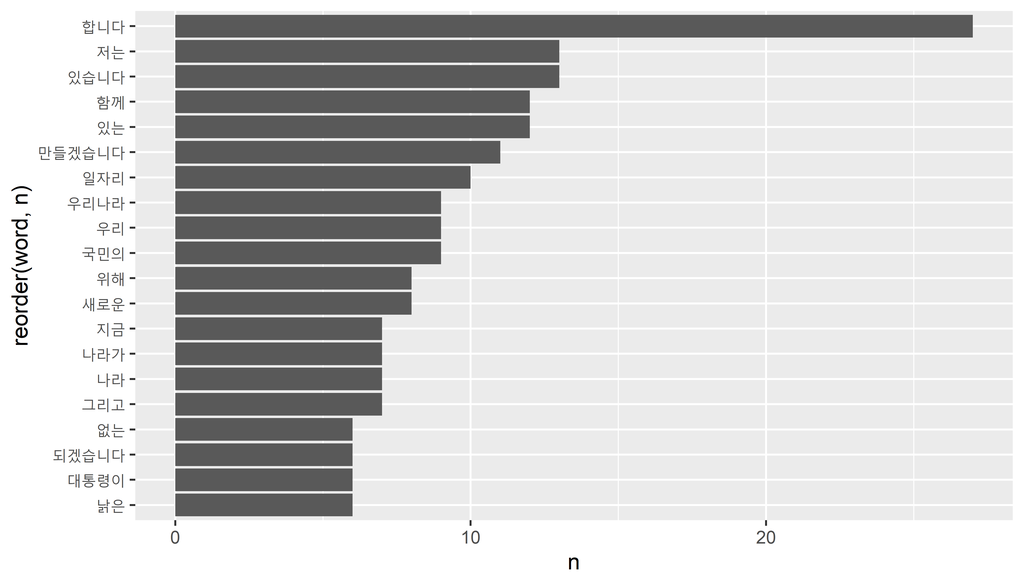

```r
library(ggplot2)

ggplot(top20, aes(x = reorder(word, n), y = n)) +  # 단어 빈도순 정렬
 geom_col() +
 coord_flip()                                      # 회전
```

[macOS에서 그래프에 한글 표현하기]

- `ggplot2` 패키지의 기본 테마 폰트를 한글 지원 폰트로 변경

```r
theme_set(theme_gray(base_family = "AppleGothic"))
```

#### 그래프 다듬기

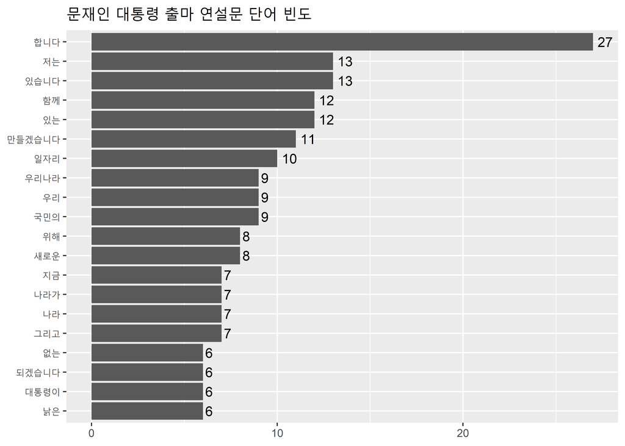

```r
ggplot(top20, aes(x = reorder(word, n), y = n)) +
 geom_col() +
 coord_flip() +
 geom_text(aes(label = n), hjust = -0.3) +            # 막대 밖 빈도 표시

 labs(title = "문재인 대통령 출마 연설문 단어 빈도",  # 그래프 제목
      x = NULL, y = NULL) +                           # 축 이름 삭제

 theme(title = element_text(size = 12))               # 제목 크기
```

#### 워드 클라우드 만들기

- 워드 클라우드(Word cloud)
  - 단어 빈도를 구름 모양으로 표현한 그래프
  - 빈도에 따라 글자 크기와 색을 다르게 표현
  - 어떤 단어가 얼마나 많이 사용됐는지 한눈에 파악

##### 워드 클라우드 만들기 - `geom_text_wordcloud()`

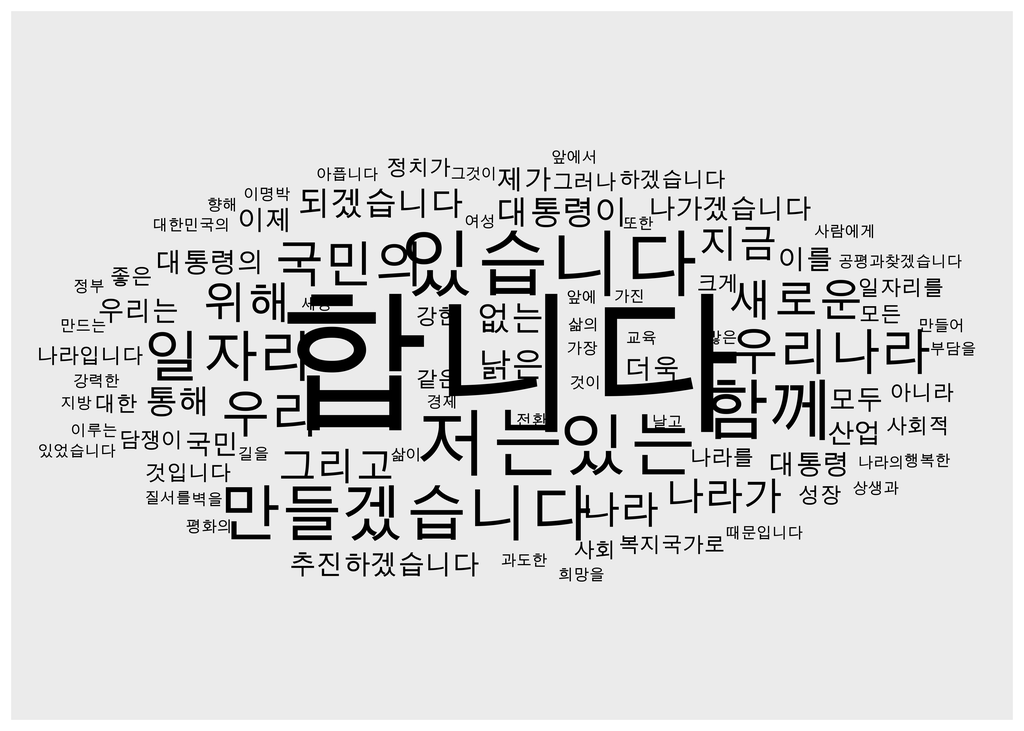

```r
install.packages("ggwordcloud")
library(ggwordcloud)

ggplot(word_space, aes(label = word, size = n)) +
 geom_text_wordcloud(seed = 1234) +
 scale_radius(limits = c(3, NA),     # 최소, 최대 단어 빈도
              range = c(3, 30))      # 최소, 최대 글자 크기
```

Plots 창 크기에 따라 그래프 모양 달라짐

##### 그래프 다듬기

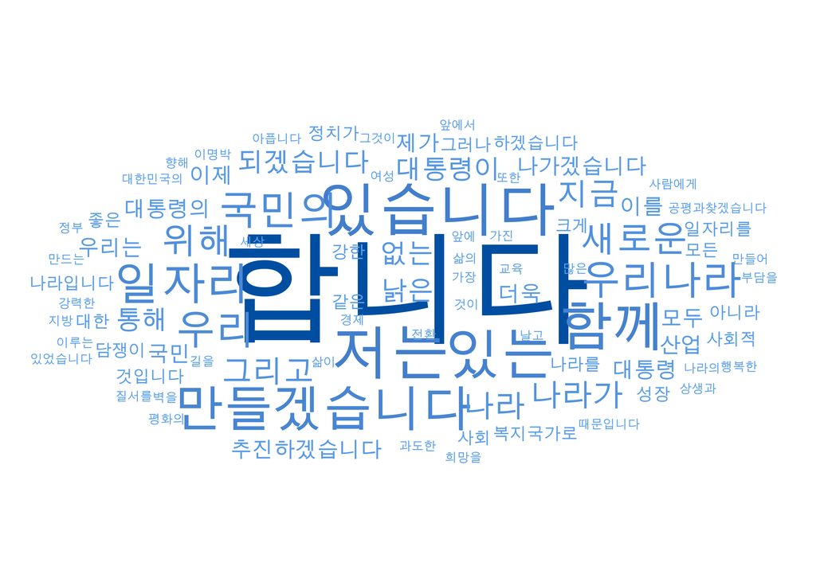

```r
ggplot(word_space,
       aes(label = word,
           size = n,
           col = n)) +                     # 빈도에 따라 색깔 표현
 geom_text_wordcloud(seed = 1234) +
 scale_radius(limits = c(3, NA),
              range = c(3, 30)) +
 scale_color_gradient(low = "#66aaf2",     # 최소 빈도 색깔
                      high = "#004EA1") +  # 최고 빈도 색깔
 theme_minimal()                           # 배경 없는 테마 적용
```

워드 클라우드 디자인 바꾸기: [lepennec.github.io/ggwordcloud](https://lepennec.github.io/ggwordcloud/)

## 4 그래프 폰트 바꾸기

#### 구글 폰트 불러오기 - `font_add_google()`

```r
install.packages("showtext")
library(showtext)

font_add_google(name = "Nanum Gothic", family = "nanumgothic")
showtext_auto()
```

fonts.google.com

##### 그래프에 폰트 지정하기

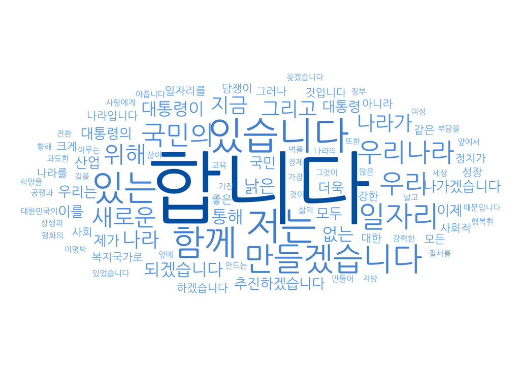

```r
ggplot(word_space,
       aes(label = word,
           size = n,
           col = n)) +
  geom_text_wordcloud(seed = 1234,
                      family = "nanumgothic") +  # 폰트 적용
  scale_radius(limits = c(3, NA),
               range = c(3, 30)) +
  scale_color_gradient(low = "#66aaf2",
                       high = "#004EA1") +
  theme_minimal()
```

#### ‘검은고딕’ 폰트 적용

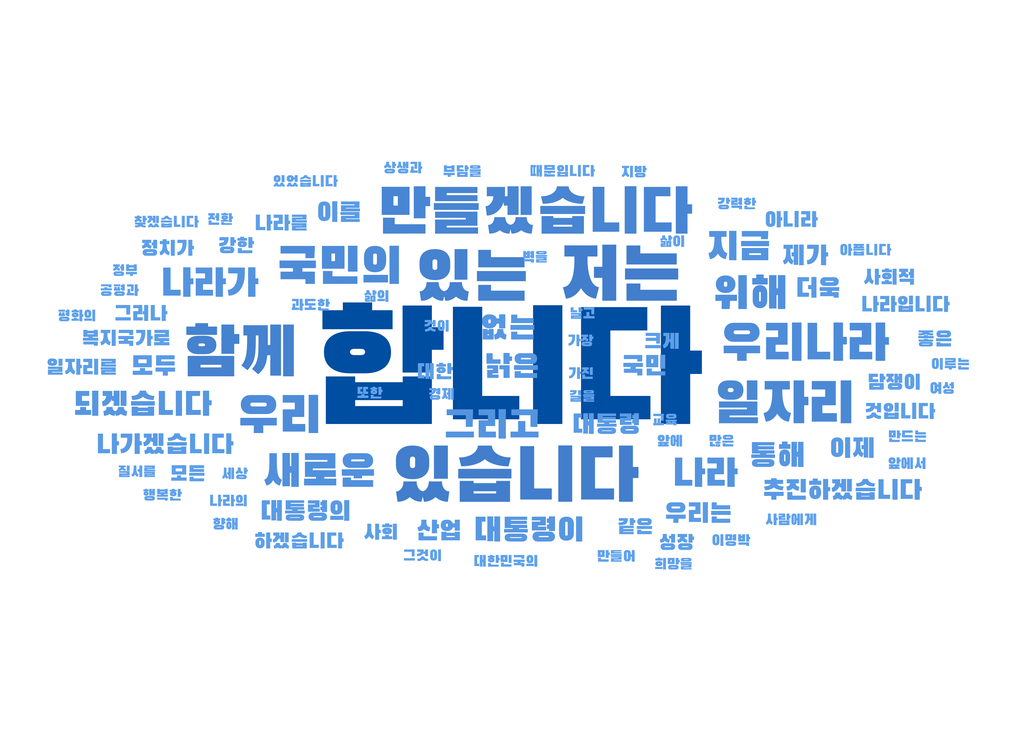

```r
font_add_google(name = "Black Han Sans", family = "blackhansans")
showtext_auto()

ggplot(word_space,
       aes(label = word,
           size = n,
           col = n)) +
  geom_text_wordcloud(seed = 1234,
                      family = "blackhansans") +  # 폰트 적용
  scale_radius(limits = c(3, NA),
               range = c(3, 30)) +
  scale_color_gradient(low = "#66aaf2",
                       high = "#004EA1") +
  theme_minimal()
```

##### `ggplot2` 패키지로 만든 그래프의 폰트 바꾸기

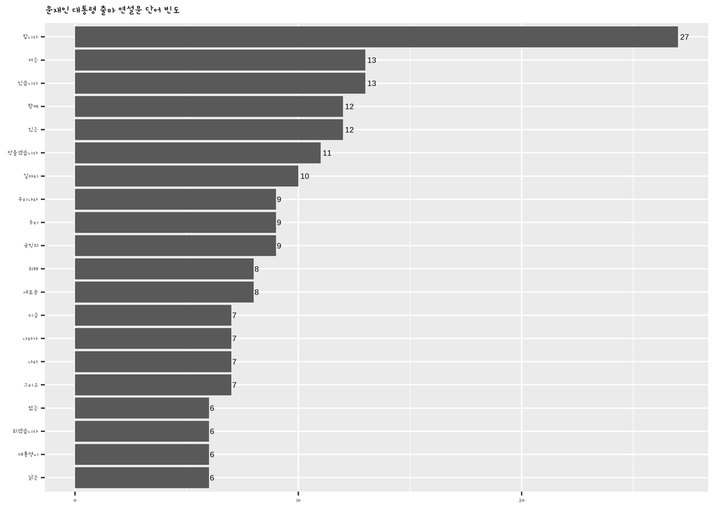

```r
font_add_google(name = "Gamja Flower", family = "gamjaflower")
showtext_auto()

ggplot(top20, aes(x = reorder(word, n), y = n)) +
  geom_col() +
  coord_flip() +
  geom_text(aes(label = n), hjust = -0.3) +

  labs(title = "문재인 대통령 출마 연설문 단어 빈도",
       x = NULL, y = NULL) +

  theme(title = element_text(size = 12),
        text = element_text(family = "gamjaflower"))  # 폰트 적용
```

RStudio를 실행할 때마다 `showtext` 패키지로 폰트를 설정해야 합니다.

### 정리하기

```r
# 전처리
moon <- raw_moon %>%
  str_replace_all("[^가-힣]", " ") %>%
  str_squish() %>%
  as_tibble()

# 토큰화
word_space <- moon %>%
  unnest_tokens(input = value,
                output = word,
                token = "words")

# 단어 빈도 구하기
word_space <- word_space %>%
  count(word, sort = T) %>%
  filter(str_count(word) > 1)

# 자주 사용된 단어 추출
top20 <- word_space %>%
  head(20)
```